# Homework: Multiple Linear Regression on the mtcars Data

# 1. Data set and question

**Data:** `mtcars`, built into R. It has 32 cars (1973-74 models) from *Motor Trend* magazine.

**Question:** What predicts a car’s fuel economy (`mpg`, miles per gallon)?

**Response:** `mpg`

**Predictors:**

| Variable | Meaning |
| --- | --- |
| `wt` | Weight (1000 lbs) |
| `hp` | Gross horsepower |
| `qsec` | Time for a quarter mile (seconds); higher means slower acceleration |
| `am` | Transmission: automatic or manual |

```r
d <- mtcars
d$am <- factor(d$am, labels = c("automatic", "manual"))

str(d[, c("mpg", "wt", "hp", "qsec", "am")])
```

```
## 'data.frame':    32 obs. of  5 variables:
##  $ mpg : num  21 21 22.8 21.4 18.7 18.1 14.3 24.4 22.8 19.2 ...
##  $ wt  : num  2.62 2.88 2.32 3.21 3.44 ...
##  $ hp  : num  110 110 93 110 175 105 245 62 95 123 ...
##  $ qsec: num  16.5 17 18.6 19.4 17 ...
##  $ am  : Factor w/ 2 levels "automatic","manual": 2 2 2 1 1 1 1 1 1 1 ...
```

```r
summary(d[, c("mpg", "wt", "hp", "qsec", "am")])
```

```
##       mpg              wt              hp             qsec               am
##  Min.   :10.40   Min.   :1.513   Min.   : 52.0   Min.   :14.50   automatic:19
##  1st Qu.:15.43   1st Qu.:2.581   1st Qu.: 96.5   1st Qu.:16.89   manual   :13
##  Median :19.20   Median :3.325   Median :123.0   Median :17.71
##  Mean   :20.09   Mean   :3.217   Mean   :146.7   Mean   :17.85
##  3rd Qu.:22.80   3rd Qu.:3.610   3rd Qu.:180.0   3rd Qu.:18.90
##  Max.   :33.90   Max.   :5.424   Max.   :335.0   Max.   :22.90
```

# 2. Exploratory look

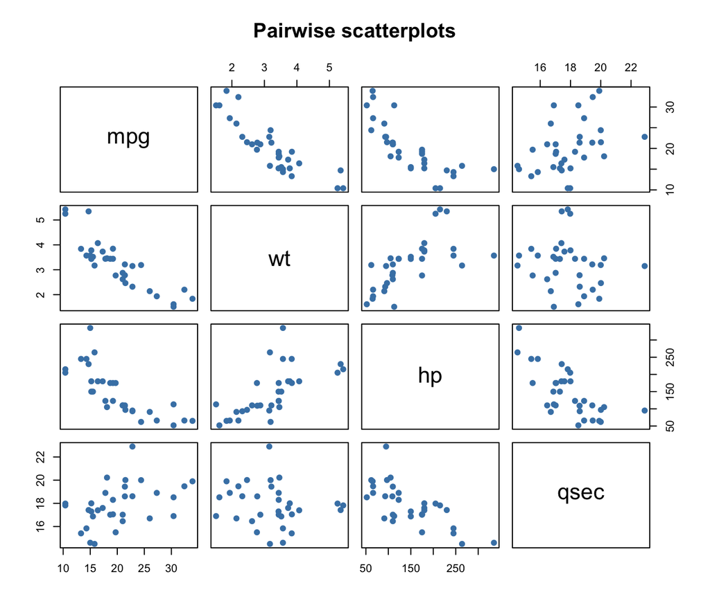

```r
pairs(d[, c("mpg", "wt", "hp", "qsec")], pch = 19, col = "steelblue",
      main = "Pairwise scatterplots")
```

```r
round(cor(d[, c("mpg", "wt", "hp", "qsec")]), 2)
```

```
##        mpg    wt    hp  qsec
## mpg   1.00 -0.87 -0.78  0.42
## wt   -0.87  1.00  0.66 -0.17
## hp   -0.78  0.66  1.00 -0.71
## qsec  0.42 -0.17 -0.71  1.00
```

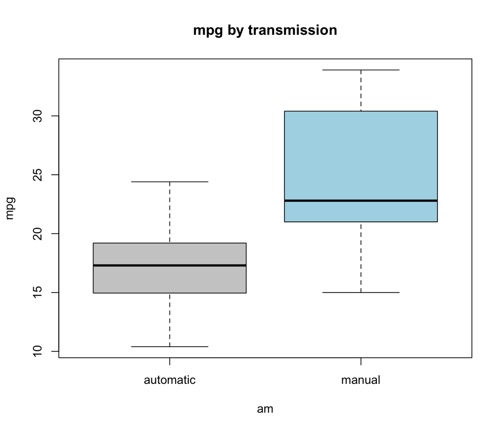

```r
boxplot(mpg ~ am, data = d, col = c("grey80", "lightblue"),
        ylab = "mpg", main = "mpg by transmission")
```

**Observations:**

- `mpg` falls strongly as `wt` (r = -0.87) and `hp` (r = -0.78) increase.
- `wt` and `hp` are correlated with each other (r = 0.66), and `hp` and `qsec` are correlated too (r = -0.71). This is a warning about multicollinearity, which we check in Section 6.
- Manual cars have higher mpg on average, but manual cars are also lighter, so we need the regression to separate these effects.

# 3. Fit the model

$$\text{mpg} = \beta_0 + \beta_1\,\text{wt} + \beta_2\,\text{hp} +
\beta_3\,\text{qsec} + \beta_4\,\text{manual} + \varepsilon$$

```r
m <- lm(mpg ~ wt + hp + qsec + am, data = d)
summary(m)
```

```
##
## Call:
## lm(formula = mpg ~ wt + hp + qsec + am, data = d)
##
## Residuals:
##     Min      1Q  Median      3Q     Max
## -3.4975 -1.5902 -0.1122  1.1795  4.5404
##
## Coefficients:
##             Estimate Std. Error t value Pr(>|t|)
## (Intercept) 17.44019    9.31887   1.871  0.07215 .
## wt          -3.23810    0.88990  -3.639  0.00114 **
## hp          -0.01765    0.01415  -1.247  0.22309
## qsec         0.81060    0.43887   1.847  0.07573 .
## ammanual     2.92550    1.39715   2.094  0.04579 *
## ---
## Signif. codes:  0 '***' 0.001 '**' 0.01 '*' 0.05 '.' 0.1 ' ' 1
##
## Residual standard error: 2.435 on 27 degrees of freedom
## Multiple R-squared:  0.8579, Adjusted R-squared:  0.8368
## F-statistic: 40.74 on 4 and 27 DF,  p-value: 4.589e-11
```

```r
confint(m)
```

```
##                   2.5 %     97.5 %
## (Intercept) -1.68054821 36.5609304
## wt          -5.06401789 -1.4121758
## hp          -0.04668118  0.0113881
## qsec        -0.08988486  1.7110899
## ammanual     0.05879488  5.7922130
```

# 4. Interpretation of the results

## Coefficients

Each slope is the expected change in `mpg` for a one-unit increase in that predictor, **holding the other predictors constant**.

| Term | Estimate | p-value | Interpretation |
| --- | --- | --- | --- |
| Intercept | 17.44 | 0.072 | Predicted mpg for an automatic car with wt = 0, hp = 0, qsec = 0. This is outside the data range, so it has no practical meaning. |
| `wt` | -3.24 | 0.001 | Each extra 1000 lbs lowers mpg by about 3.2, holding hp, qsec and transmission fixed. Significant; 95% CI: -5.06 to -1.41. |
| `hp` | -0.018 | 0.223 | Each extra horsepower lowers mpg by about 0.02, holding the others fixed. Not significant; the CI (-0.047 to 0.011) includes 0. |
| `qsec` | 0.81 | 0.076 | A car that is 1 second slower over the quarter mile gets about 0.8 more mpg, holding the others fixed. Only weak evidence (p < 0.10). |
| `am` (manual) | 2.93 | 0.046 | Manual cars average about 2.9 more mpg than automatics with the same weight, hp and qsec. Significant at 5%; the CI (0.06 to 5.79) is wide. |

**Take-away:** weight is the strongest predictor. Once weight is in the model, horsepower adds little.

## Overall fit

- **R² = 0.858:** the four predictors together explain about 86% of the variation in mpg.
- **Adjusted R² = 0.837:** the same figure penalized for the number of predictors, which is the fairer measure when comparing models.
- **Residual standard error = 2.44:** predictions are typically off by about 2.4 mpg.
- **F-test:** F = 40.7 on 4 and 27 df, p < 0.001. At least one predictor is related to mpg, so the model is far better than using the mean alone.

# 5. Check the assumptions

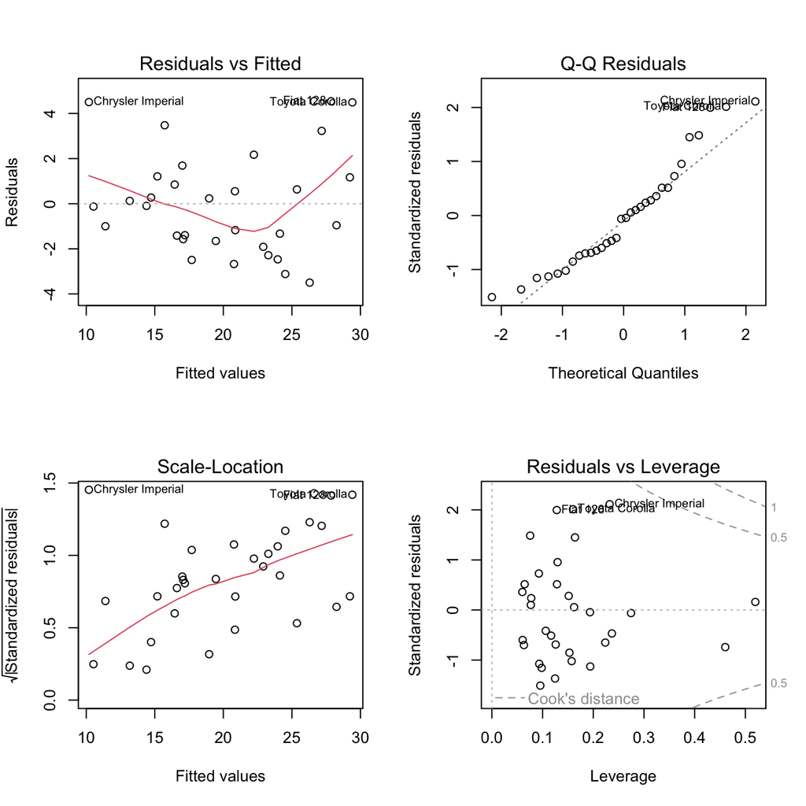

```r
par(mfrow = c(2, 2))
plot(m)
```

```r
par(mfrow = c(1, 1))

shapiro.test(resid(m))
```

```
##
##  Shapiro-Wilk normality test
##
## data:  resid(m)
## W = 0.93924, p-value = 0.07126
```

# 6. Multicollinearity

Variance inflation factors (VIF), computed by hand so no extra package is needed:

```r
X <- model.matrix(m)[, -1]
vif <- sapply(colnames(X), function(j) {
  r2 <- summary(lm(X[, j] ~ X[, colnames(X) != j]))$r.squared
  1 / (1 - r2)
})
round(vif, 2)
```

```
##       wt       hp     qsec ammanual
##     3.96     4.92     3.22     2.54
```

All VIFs are below 5 (`hp` is highest at about 4.9). That is not severe, but it is high enough to explain why `hp` and `qsec` are not significant: they overlap with `wt` and with each other, so each one’s *unique* contribution is small.

# 7. Simplify the model

`hp` is not significant, so test whether dropping it hurts the fit:

```r
r <- lm(mpg ~ wt + qsec + am, data = d)
summary(r)
```

```
##
## Call:
## lm(formula = mpg ~ wt + qsec + am, data = d)
##
## Residuals:
##     Min      1Q  Median      3Q     Max
## -3.4811 -1.5555 -0.7257  1.4110  4.6610
##
## Coefficients:
##             Estimate Std. Error t value Pr(>|t|)
## (Intercept)   9.6178     6.9596   1.382 0.177915
## wt           -3.9165     0.7112  -5.507 6.95e-06 ***
## qsec          1.2259     0.2887   4.247 0.000216 ***
## ammanual      2.9358     1.4109   2.081 0.046716 *
## ---
## Signif. codes:  0 '***' 0.001 '**' 0.01 '*' 0.05 '.' 0.1 ' ' 1
##
## Residual standard error: 2.459 on 28 degrees of freedom
## Multiple R-squared:  0.8497, Adjusted R-squared:  0.8336
## F-statistic: 52.75 on 3 and 28 DF,  p-value: 1.21e-11
```

```r
anova(r, m)          # F-test: is hp needed?
```

```
## Analysis of Variance Table
##
## Model 1: mpg ~ wt + qsec + am
## Model 2: mpg ~ wt + hp + qsec + am
##   Res.Df    RSS Df Sum of Sq      F Pr(>F)
## 1     28 169.29
## 2     27 160.07  1    9.2195 1.5551 0.2231
```

```r
AIC(m, r)
```

```
##   df      AIC
## m  6 154.3274
## r  5 154.1194
```

- The F-test (p = 0.223) shows that `hp` does not significantly improve the model.
- AIC is essentially the same (154.3 vs 154.1), and adjusted R² is almost unchanged (0.834 vs 0.837).
- In the reduced model, `wt` (p < 0.001), `qsec` (p < 0.001) and `am` (p = 0.047) are all significant. Once the overlapping `hp` is removed, `qsec` becomes clearly significant.

The simpler model `mpg ~ wt + qsec + am` is preferable: it fits about as well with fewer predictors.

# 8. Prediction example

Predict mpg for a manual car weighing 3000 lbs, with 120 hp and a quarter-mile time of 18 seconds:

```r
nd <- data.frame(wt = 3, hp = 120, qsec = 18,
                 am = factor("manual", levels = levels(d$am)))

predict(m, nd, interval = "confidence")   # for the average of such cars
```

```
##        fit      lwr      upr
## 1 23.12467 21.31786 24.93147
```

```r
predict(m, nd, interval = "prediction")   # for one individual car
```

```
##        fit      lwr      upr
## 1 23.12467 17.81212 28.43721
```

The predicted mpg is about 23.1. We are 95% confident that the *average* mpg of such cars is between about 21.3 and 24.9, but an *individual* car could plausibly land anywhere between about 17.8 and 28.4.

# 9. Conclusion and limitations